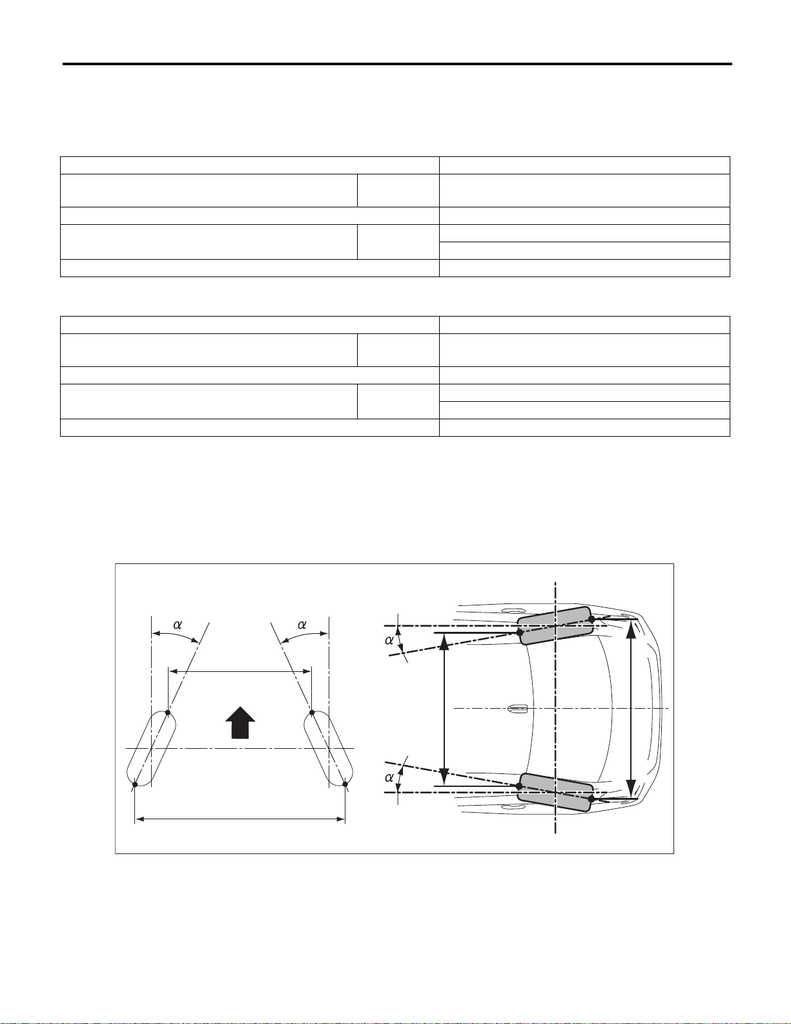

RS-2

General Description

REAR SUSPENSION

1. General Description

A: SPECIFICATION

1. WRX MODEL

2. STI MODEL

NOTE:

• Front toe-in, rear toe-in and front camber can be adjusted. Adjust if the value of toe-in or camber exceeds

the tolerance range of the specification chart.

• Other items except for front toe-in, rear toe-in and front camber that are described in the specification chart

cannot be adjusted.

• If other items exceed the tolerance range of the specification chart, check the suspension parts and con-

nections for deformation. If defective, replace with new parts.

A – B = Positive: Toe-in, Negative: Toe-out

α

= Individual toe angles

Tire size 235/45R17

Wheel arch height

(Tolerance:

+12 mm

–24 mm

(

+0.47 in

–0.94 in

))

mm (in) 367 (14.45)

Camber (tolerance: ±0°45′ Differences between RH and LH: 45′ or less) –1°30′

Toe-in mm (in)

IN3±3 (IN0.12±0.12)

Toe angle (sum of both wheels): IN0°16′±16′

Thrust angle (tolerance: 0°00′±30′) 0°00′

Tire size 245/40R18

Wheel arch height

(Tolerance:

+12 mm

–24 mm

(

+0.47 in

–0.94 in

))

mm (in) 362 (14.25)

Camber (tolerance: ±0°45′ Differences between RH and LH: 45′ or less) –1°40′

Toe-in mm (in)

IN3±3 (IN0.12±0.12)

Toe angle (sum of both wheels): IN0°16′±16′

Thrust angle (tolerance: 0°00′±30′) 0°00′

A

B

RS-00537

B

A

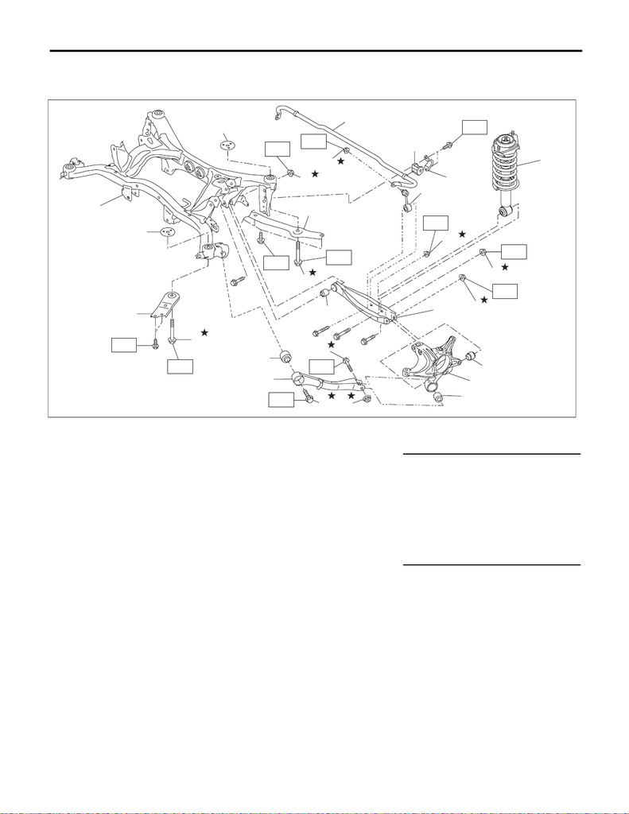

RS-3

General Description

REAR SUSPENSION

B: COMPONENT

1. REAR SUSPENSION

(1) Rear sub frame ASSY (11) Rear support sub frame (21) Bushing - trailing link

(2) Stopper UPR (12) Flange nut

(3) Support - sub frame (13) Rear stabilizer Tightening torque: N·m (kgf-m, ft-lb)

(4) Flange bolt A (14) Bushing - stabilizer T1: 30 (3.1, 22.1)

(5) Bushing A - trailing link (15) Clamp - stabilizer bushing T2: 38 (3.9, 28.0)

(6) Trailing link (16) Stabilizer link ASSY T3: 70 (7.1, 51.6)

(7) Flange bolt B (17) Rear shock absorber ASSY T4: 80 (8.2, 59.0)

(8) Self-locking nut (18) Rear lateral link ASSY T5: 85 (8.7, 62.7)

(9) Flange bolt C (19) Bushing - rear axle housing T6: 110 (11.2, 81.1)

(10) Bushing C - lateral link rear (20) Housing ASSY - rear axle T7: 145 (14.8, 106.9)

RS-00539

(12)

(8)

(1)

(2)

(3)

(4)

(10)

(4)

(15)

(20)

(16)

(5)

(9)

(8)

(14)

(19)

(18)

(13)

(21)

(12)

(6)

(17)

T2

T6

T3

(7)

T6

T3

T4

(8)

T5

T4

T2

(2)

T1

(11)

T7

T7

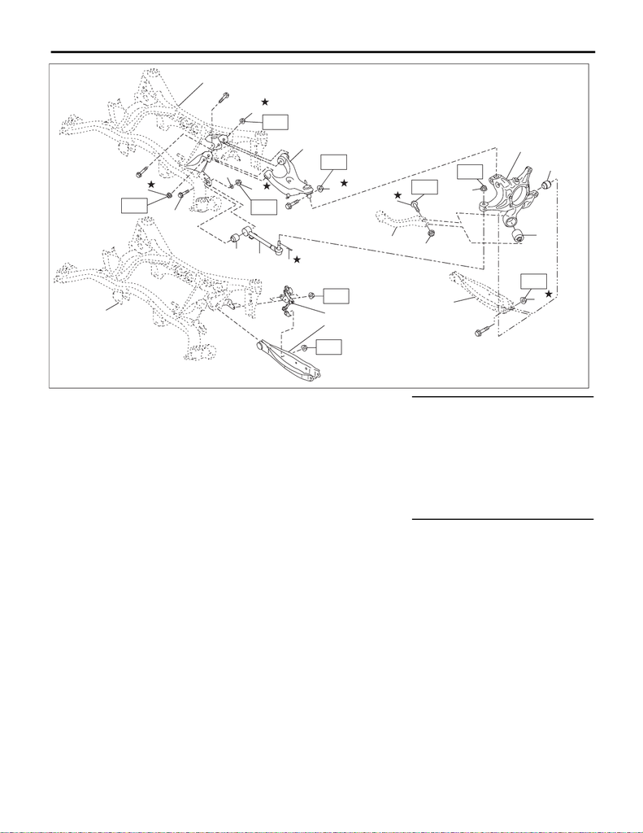

RS-4

General Description

REAR SUSPENSION

(1) Rear sub frame ASSY (9) Sensor ASSY - headlight beam

leveler (models with auto head-

light beam leveler only)

Tightening torque: N·m (kgf-m, ft-lb)

(2) Self-locking nut (10) Lateral link ASSY - rear T1: 7.5 (0.8, 5.5)

(3) Rear upper arm ASSY (11) Housing ASSY - rear axle T2: 60 (6.1, 44.3)

(4) Snap pin (12) Bushing - rear axle housing T3: 80 (8.2, 59.0)

(5) Lateral link ASSY - front (13) Bushing - trailing link T4: 90 (9.2, 66.4)

(6) Bushing B - lateral link (14) Flange nut T5: 100 (10.2, 73.8)

(7) Adjusting washer (15) Trailing link T6: 110 (11.2, 81.1)

(8) Adjusting bolt (16) Flange bolt

RS-00538

(2)

(16)

T6

(12)

(13)

(11)

(10)

(1)

(8)

(7)

(2)

T5

(2)

T4

T4

(2)

(5)

(4)

(14)

(6)

(2)

T2

T3

(3)

T3

(2)

(1)

(10)

(9)

T1

T1

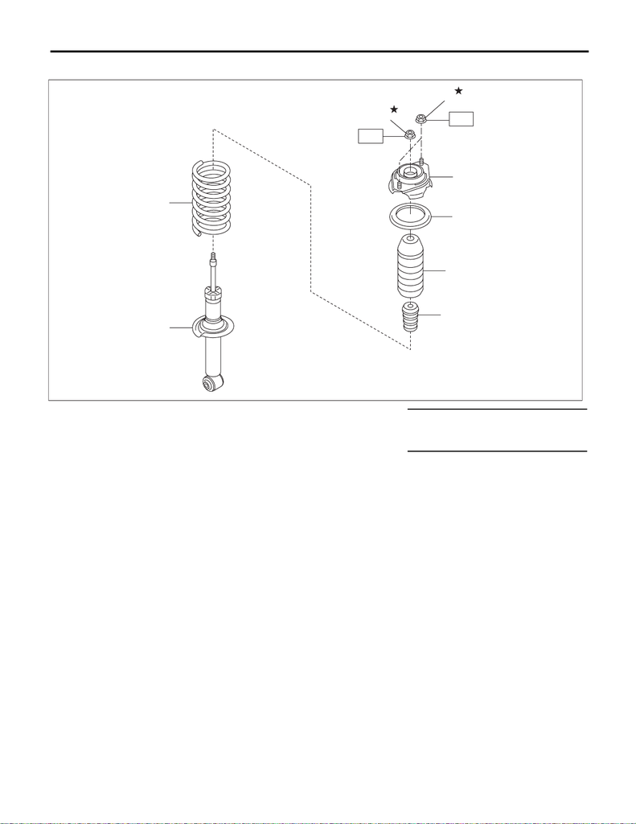

RS-5

General Description

REAR SUSPENSION

2. REAR SHOCK ABSORBER

(1) Flange nut (5) Dust cover - rear shock Tightening torque: N·m (kgf-m, ft-lb)

(2) Self-locking nut (6) Helper - rear T1: 25 (2.5, 18.4)

(3) Shock mount - rear (7) Coil spring - rear T2: 30 (3.1, 22.1)

(4) Rubber seat - shock UPR (8) Shock absorber COMPL - rear

RS-00541

T2

(1)

(4)

(5)

(7)

(8)

(6)

(2)

(3)

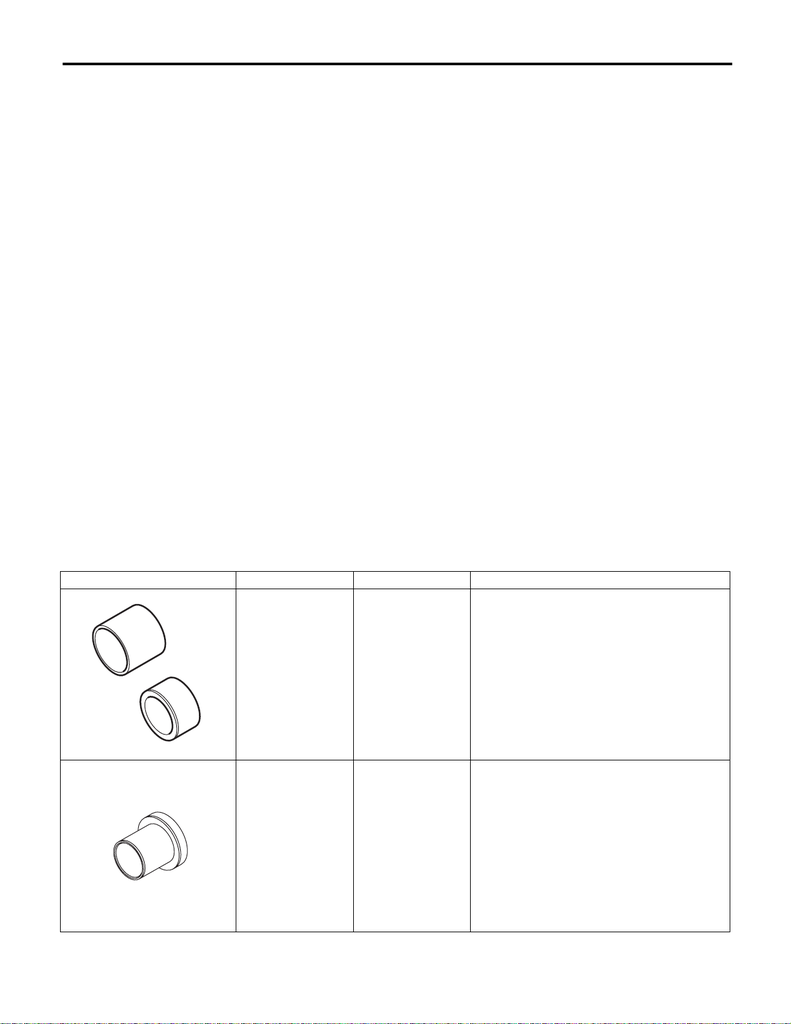

RS-6

General Description

REAR SUSPENSION

C: CAUTION

• When performing any work, always wear work clothes, a work cap and protective shoes. Additionally, wear

a helmet, protective goggles, etc. if necessary.

• When disposing of shock absorbers, be sure to bleed the oil or gas out completely. Also, do not expose to

flames or fire.

• When performing a repair, identify the cause of trouble and avoid unnecessary removal, disassembly and

replacement.

• Use SUBARU genuine grease, the recommended or equivalent. Do not mix grease etc. of different grades

or manufacturers.

• Do not secure a part in a vise directly. Place cushioning materials such as wood blocks, aluminum plates,

or waste cloth between the part and the vise.

• Be sure to tighten fasteners including bolts and nuts to the specified torque.

• Always use the jack-up point when the shop jacks or rigid racks are used to support the vehicle.

• When the suspension-related components have been removed/installed or replaced, perform “VDC sen-

sor midpoint setting mode” of the VDC. <Ref. to VDC-16, ADJUSTMENT, VDC Control Module and Hydrau-

lic Control Unit (VDCCM&H/U).>

• For parts which are not reusable, always use new parts. Other parts should be replaced with new parts as

required.

• When handling oil or fuel, adhere to the following to prevent unexpected accident.

– Be careful with fire.

– Prepare a container to catch grease or oil, etc. If any grease or oil spills, wipe it off and clean immedi-

ately to prevent from penetrating into floor or flowing outside.

– Follow all government and local regulations concerning disposal of refuse when disposing.

• Be sure that the surface of brake disc or brake pad is free from grease or oil.

• Before disconnecting connectors of sensors or units, be sure to disconnect the ground cable from battery.

• Some vehicle components are extremely hot immediately after driving. Be wary of receiving burns from

heated parts.

D: PREPARATION TOOL

1. SPECIAL TOOL

ILLUSTRATION TOOL NUMBER DESCRIPTION REMARKS

20099PA010 INSTALLER &

REMOVER

• Used for replacing the bushing A - trailing link

of the housing assembly - rear axle.

• Used together with BUSHING REMOVER

(20099FG000).

20099FG000 BUSHING

REMOVER

• Used for replacing the bushing A - trailing link

of the housing assembly - rear axle.

ST20099PA010

ST20099FG000

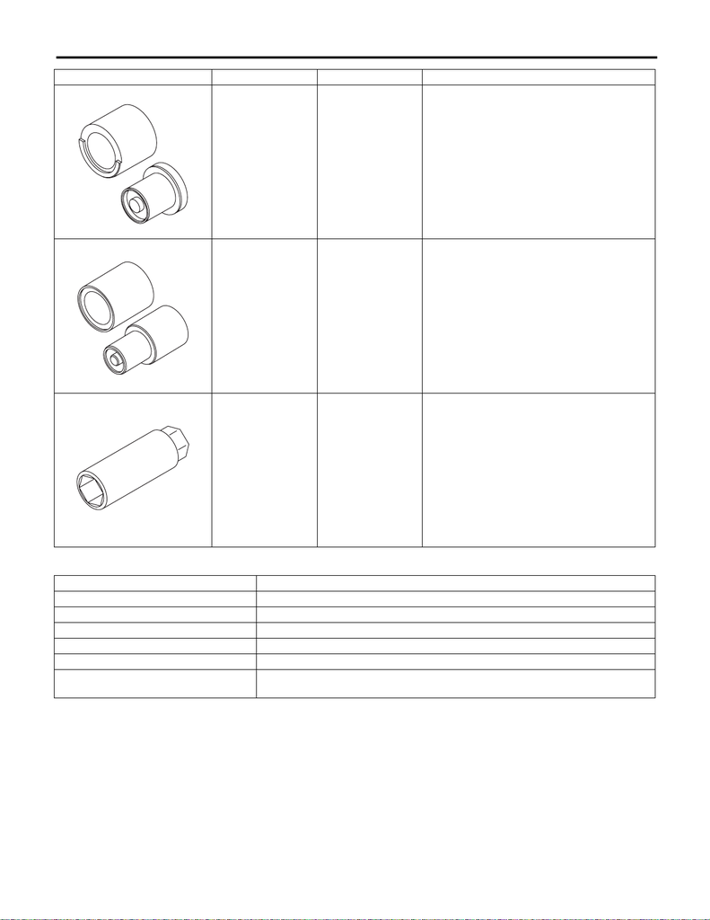

RS-7

General Description

REAR SUSPENSION

20099AE000 INSTALLER &

REMOVER

Used for replacing the bushing B - lateral link.

20099AE010 INSTALLER &

REMOVER

Used for replacing the bushing C - lateral link.

20399FG000 STRUT MOUNT

SOCKET

• Used for disassembling and assembling strut

assembly and shock absorber assembly.

• Used for checking center nut torque of strut

assembly and shock absorber assembly.

TOOL NAME REMARKS

Alignment tester Used for measuring wheel alignment.

Toe-in gauge Used for toe-in measurement.

Jack Used for removing and installing suspension.

Bearing puller Used for removing bushings.

Tie-rod ball joint puller Used for disconnecting the lateral link assembly - front.

Coil spring compressor Used for disassembling and assembling strut assembly and shock absorber assem-

bly.

ILLUSTRATION TOOL NUMBER DESCRIPTION REMARKS

ST20099AE000

ST20099AE010

ST20399FG000